# NL BMDA Final Project: Glucocorticoid Response in Airway Smooth Muscle Cells

Nat Lim

2026-06-13

### 1. Background and Question

Asthma is a chronic inflammatory airway disease, and inhaled corticosteroids (synthetic glucocorticoids like dexamethasone) are a first-line treatment because they suppress inflammation in airway smooth muscle (ASM). However, not all patients respond equally well, and the full transcriptional program that glucocorticoids switch on in ASM cells is still being mapped out.

##### **Dataset:**

Himes et al. (2014) treated four primary human ASM cell lines with 1 micromolar dexamethasone (or vehicle control) for 18 hours and ran RNA-seq on all eight samples (paired design: each donor cell line contributes one treated and one untreated sample). Data are deposited at GEO under accession **GSE52778** and are also distributed as a pre-counted, analysis-ready object in the Bioconductor `airway` package.

##### **Question:**

Which genes are significantly up- or down-regulated in human ASM cells after dexamethasone treatment, and do our top hits recover genes already implicated in glucocorticoid/asthma biology in the literature?

This matters because genes that consistently respond to corticosteroids in ASM are candidates for understanding (and eventually predicting) corticosteroid response/resistance in asthma patients.

### 2. Data Acquisition

```r
# This is set to eval=FALSE because it only needs to be run the first time the code is run
if (!requireNamespace("BiocManager", quietly = TRUE)) install.packages("BiocManager")
BiocManager::install(c("airway", "DESeq2", "SummarizedExperiment", "pheatmap",
                        "org.Hs.eg.db", "AnnotationDbi", "apeglm"))
```

```r
# airway: this is our data acquisition step. The package is directly loaded with the
# gene-level count matrix from Himes et al. 2014 (GEO: GSE52778).
library(airway)
# DESeq2: the statistical engine for the whole project. It models raw RNA-seq counts with
# a negative binomial GLM, which correctly handles the mean-variance relationship in count
# data.
library(DESeq2)
# SummarizedExperiment: airway's data lives in this container class; we need its accessor
# functions (assay(), colData()) to pull out the count matrix and sample metadata.
library(SummarizedExperiment)
# ggplot2: used for the PCA and volcano plots
library(ggplot2)
# pheatmap: a quick, clean way to draw the top-gene expression heatmap.
library(pheatmap)
# org.Hs.eg.db + AnnotationDbi: airway's count matrix is indexed by Ensembl gene ID
# (e.g. ENSG00000103196), which nobody can interpret on sight. This annotation database
# lets us map IDs to human-readable gene symbols (e.g. CRISPLD2) for interpretation.
library(org.Hs.eg.db)
library(AnnotationDbi)
# apeglm: provides a shrunken, more reliable log2 fold-change estimator than the raw MLE,
# which matters because raw fold-changes for low-count genes are extremely noisy and would
# otherwise dominate a naive "rank by fold-change" approach.
library(apeglm)
```

```r
# data() loads the airway SummarizedExperiment that ships inside the package.
data("airway")
se <- airway
# colData() holds sample-level metadata. Print allows confirmation that this is
# a paired design: 4 donor cell lines, each with one "trt" (dex) and one "untrt" sample.
colData(se)
```

```
## DataFrame with 8 rows and 9 columns
##            SampleName     cell      dex    albut        Run avgLength
##              <factor> <factor> <factor> <factor>   <factor> <integer>
## SRR1039508 GSM1275862  N61311     untrt    untrt SRR1039508       126
## SRR1039509 GSM1275863  N61311     trt      untrt SRR1039509       126
## SRR1039512 GSM1275866  N052611    untrt    untrt SRR1039512       126
## SRR1039513 GSM1275867  N052611    trt      untrt SRR1039513        87
## SRR1039516 GSM1275870  N080611    untrt    untrt SRR1039516       120
## SRR1039517 GSM1275871  N080611    trt      untrt SRR1039517       126
## SRR1039520 GSM1275874  N061011    untrt    untrt SRR1039520       101
## SRR1039521 GSM1275875  N061011    trt      untrt SRR1039521        98
##            Experiment    Sample    BioSample
##              <factor>  <factor>     <factor>
## SRR1039508  SRX384345 SRS508568 SAMN02422669
## SRR1039509  SRX384346 SRS508567 SAMN02422675
## SRR1039512  SRX384349 SRS508571 SAMN02422678
## SRR1039513  SRX384350 SRS508572 SAMN02422670
## SRR1039516  SRX384353 SRS508575 SAMN02422682
## SRR1039517  SRX384354 SRS508576 SAMN02422673
## SRR1039520  SRX384357 SRS508579 SAMN02422683
## SRR1039521  SRX384358 SRS508580 SAMN02422677
```

```r
# assay() pulls out the gene x sample count matrix itself. Checking dim() before any
# filtering gives us a concrete starting number to report in the QC section.
dim(assay(se))
```

```
## [1] 63677     8
```

### 3. Preprocessing / QC

```r
# Most of the ~64,000 annotated genes have zero or near-zero counts in ASM cells
# as they are not expressed in airway smooth muscle cells. As such, any gene with
# fewer than 10 total reads is filtered out across all 8 samples.
keep <- rowSums(assay(se)) >= 10
se_filtered <- se[keep, ]

cat("Genes before filtering:", nrow(se), "\n")
```

```
## Genes before filtering: 63677
```

```r
cat("Genes after filtering: ", nrow(se_filtered), "\n")
```

```
## Genes after filtering:  22369
```

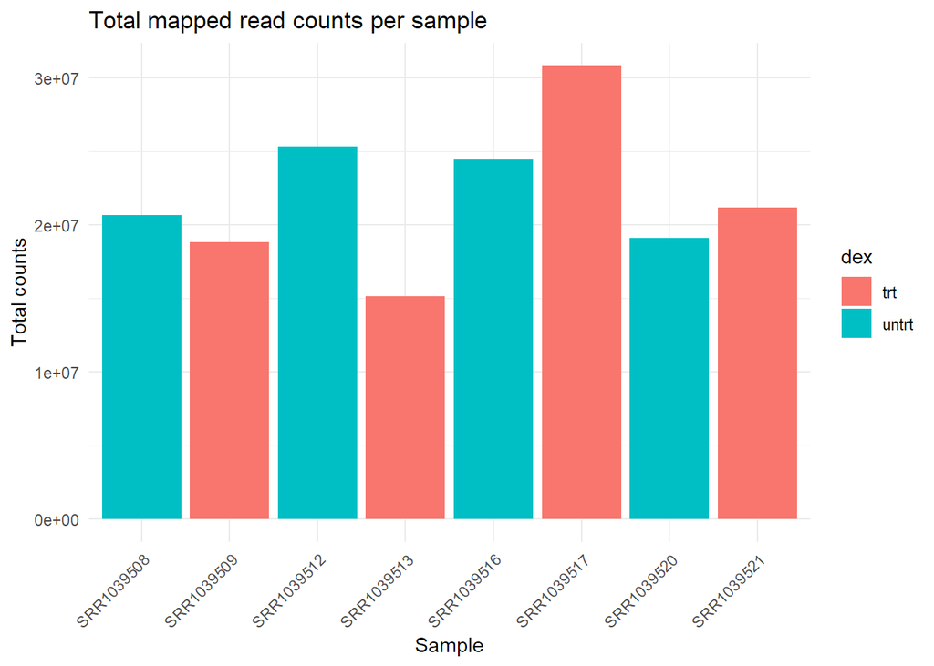

```r
# Sequencing depth naturally varies sample to sample. We plot total counts per sample here
# purely as a QC check: if one sample were a severe outlier (e.g. 10x lower depth than the
# rest), that would be a red flag to investigate before trusting any downstream comparison.
libsize_df <- data.frame(
  sample = colnames(se_filtered),
  total_counts = colSums(assay(se_filtered)),
  dex = colData(se_filtered)$dex
)

ggplot(libsize_df, aes(x = sample, y = total_counts, fill = dex)) +
  geom_col() +
  theme_minimal() +
  theme(axis.text.x = element_text(angle = 45, hjust = 1)) +
  labs(title = "Total mapped read counts per sample", x = "Sample", y = "Total counts")
```

### 4. Statistical Analysis: DESeq2

Using **DESeq2** rather than a simple fold-change cutoff or t-test because RNA-seq counts are discrete, over-dispersed, and heteroskedastic (variance grows with the mean). DESeq2’s negative-binomial GLM with empirical Bayes dispersion shrinkage is built specifically to model that, and gives us calibrated p-values even with only n = 4 replicates per group.

```r
# The design formula "~ cell + dex" tells DESeq2 to first account for baseline
# differences between the 4 donor cell lines (a known, paired source of variation
# each line contributes both a treated and untreated sample), and THEN test for the dex
# effect on top of that. This mirrors the paired design used in the original study and
# increases statistical power versus ignoring donor identity entirely.
dds <- DESeqDataSet(se_filtered, design = ~ cell + dex)

# DESeq2 orders factor levels alphabetically by default, which would make "trt" the
# reference (denominator) we explicitly set "untrt" as the reference level instead, so
# that a POSITIVE log2FoldChange means "higher after dexamethasone," which is the more
# intuitive direction when we interpret results later.
dds$dex <- relevel(dds$dex, ref = "untrt")

# This single call runs the full DESeq2 pipeline: (1) median-of-ratios size factor
# normalization to correct for sequencing depth differences between samples, (2) per-gene
# dispersion estimation that borrows information across genes (necessary because 4
# replicates alone can't reliably estimate variance gene-by-gene), and (3) fits the negative
# binomial GLM and runs the Wald test for the dex coefficient.
dds <- DESeq(dds)
```

```r
# results() with an explicit contrast extracts the dex trt-vs-untrt comparison.
# alpha = 0.05 tells DESeq2 to optimize its internal adaptive FDR filtering for that cutoff.
res <- results(dds, contrast = c("dex", "trt", "untrt"), alpha = 0.05)

# lfcShrink replaces the raw (noisy) log2FoldChange estimates with ones shrunken toward
# zero using the apeglm method. Genes with low counts or high variance get pulled in, so
# the fold-changes we go on to RANK and PLOT reflect real effect sizes rather than sampling
# noise from a handful of reads.
res_shrunk <- lfcShrink(dds, coef = "dex_trt_vs_untrt", res = res, type = "apeglm")

# A first concrete headline number for the report/video: how many genes are significantly
# up vs down at FDR < 0.05.
summary(res_shrunk)
```

```
##
## out of 22369 with nonzero total read count
## adjusted p-value < 0.05
## LFC > 0 (up)       : 2208, 9.9%
## LFC < 0 (down)     : 1822, 8.1%
## outliers [1]       : 0, 0%
## low counts [2]     : 5204, 23%
## (mean count < 6)
## [1] see 'cooksCutoff' argument of ?results
## [2] see 'independentFiltering' argument of ?results
```

```r
# Convert to a plain data frame and keep the Ensembl ID as an explicit column (it's
# currently just the rownames, which is easy to lose track of after sorting/filtering).
res_df <- as.data.frame(res_shrunk)
res_df$ensembl_id <- rownames(res_df)

# mapIds looks up each Ensembl gene ID in org.Hs.eg.db and returns the matching gene
# symbol. We need this because "ENSG00000103196" may not be significant at first glance,
# but "CRISPLD2" is a recognizable/searchable gene.
res_df$symbol <- mapIds(org.Hs.eg.db,
                         keys = res_df$ensembl_id,
                         column = "SYMBOL",
                         keytype = "ENSEMBL",
                         multiVals = "first")

# Drop genes DESeq2 could not test (NA padj are usually genes with an extreme-count outlier
# or filtered out internally for very low mean expression), so our ranked table only
# contains genes with an actual usable result.
res_df <- res_df[!is.na(res_df$padj), ]

# Sort by adjusted p-value so row 1 is the single most significant gene.
res_df <- res_df[order(res_df$padj), ]

head(res_df, 10)
```

```
##                   baseMean log2FoldChange      lfcSE        pvalue
## ENSG00000152583   997.4447       4.559848 0.18588296 4.110667e-136
## ENSG00000165995   495.0957       3.280119 0.13320564 4.463384e-135
## ENSG00000120129  3409.0384       2.936591 0.12250238 3.033840e-129
## ENSG00000101347 12703.4128       3.754342 0.15761012 7.682657e-129
## ENSG00000189221  2341.7807       3.341300 0.14323399 5.212706e-123
## ENSG00000211445 12285.7001       3.716111 0.16848271 2.585059e-111
## ENSG00000157214  3009.2729       1.969256 0.09063106 6.091349e-106
## ENSG00000162614  5393.1145       2.027830 0.09495834 1.565462e-102
## ENSG00000125148  3656.2674       2.198752 0.10650627  1.849644e-96
## ENSG00000154734 30315.1132       2.334542 0.11700233  2.266757e-90
##                          padj      ensembl_id  symbol
## ENSG00000152583 7.055960e-132 ENSG00000152583 SPARCL1
## ENSG00000165995 3.830700e-131 ENSG00000165995  CACNB2
## ENSG00000120129 1.735862e-125 ENSG00000120129   DUSP1
## ENSG00000101347 3.296820e-125 ENSG00000101347  SAMHD1
## ENSG00000189221 1.789522e-119 ENSG00000189221    MAOA
## ENSG00000211445 7.395423e-108 ENSG00000211445    GPX3
## ENSG00000157214 1.493686e-102 ENSG00000157214  STEAP2
## ENSG00000162614  3.358895e-99 ENSG00000162614    NEXN
## ENSG00000125148  3.527683e-93 ENSG00000125148    MT2A
## ENSG00000154734  3.890888e-87 ENSG00000154734 ADAMTS1
```

### 5. Visualization

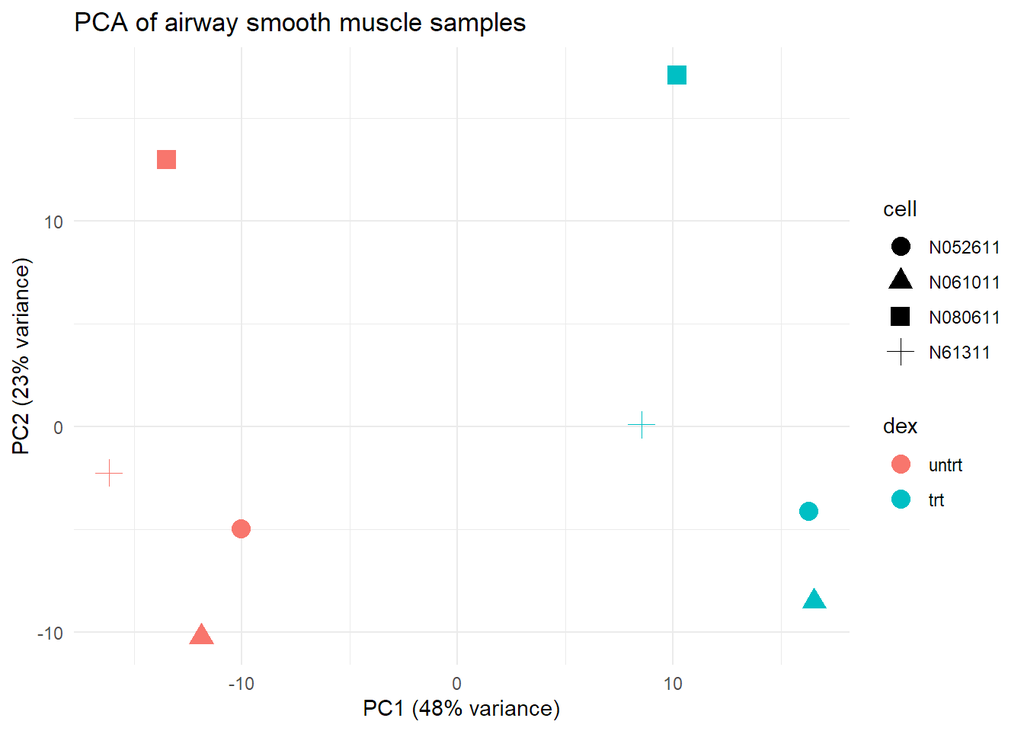

```r
# vst() (variance-stabilizing transformation) puts the data on a roughly homoskedastic
# scale suitable for distance-based methods like PCA so the results will not be primarily
# made up of very highly-expressed genes rather than overall sample similarity.
vsd <- vst(dds, blind = FALSE)

# returnData = TRUE gives us the raw PC coordinates instead of DESeq2's default base plot,
# so we can re-draw it in ggplot2 with full control over color/shape/styling.
pca_data <- plotPCA(vsd, intgroup = c("dex", "cell"), returnData = TRUE)
percentVar <- round(100 * attr(pca_data, "percentVar"))

ggplot(pca_data, aes(x = PC1, y = PC2, color = dex, shape = cell)) +
  geom_point(size = 4) +
  labs(
    title = "PCA of airway smooth muscle samples",
    x = paste0("PC1 (", percentVar[1], "% variance)"),
    y = paste0("PC2 (", percentVar[2], "% variance)")
  ) +
  theme_minimal()
```

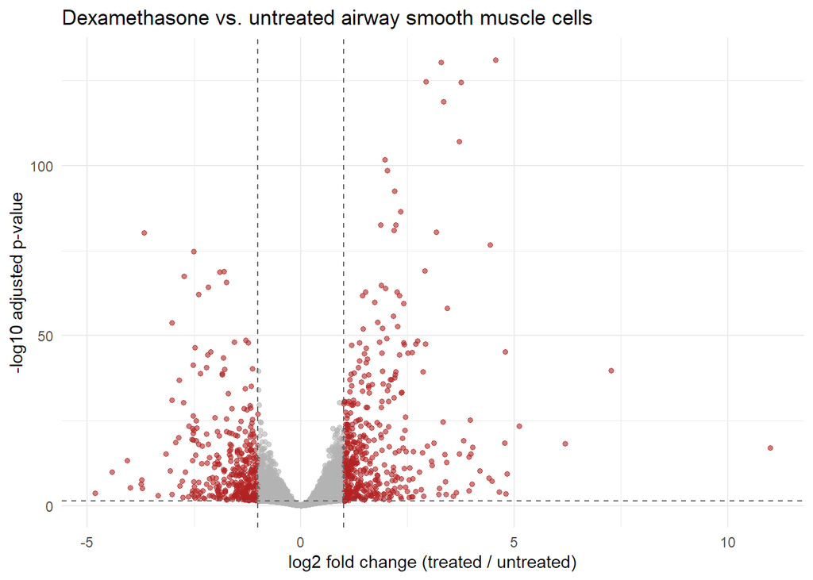

```r
# Flag genes as "significant" using BOTH an FDR cutoff AND a minimum effect size, not just
# a p-value cutoff alone to avoid highlighting genes that are "significant" purely
# because of statistical power but have a trivially small, biologically uninteresting
# fold-change.
res_df$significant <- with(res_df, padj < 0.05 & abs(log2FoldChange) > 1)

ggplot(res_df, aes(x = log2FoldChange, y = -log10(padj), color = significant)) +
  geom_point(alpha = 0.6, size = 1.2) +
  scale_color_manual(values = c("grey70", "firebrick")) +
  geom_vline(xintercept = c(-1, 1), linetype = "dashed", color = "grey40") +
  geom_hline(yintercept = -log10(0.05), linetype = "dashed", color = "grey40") +
  labs(
    title = "Dexamethasone vs. untreated airway smooth muscle cells",
    x = "log2 fold change (treated / untreated)",
    y = "-log10 adjusted p-value"
  ) +
  theme_minimal() +
  theme(legend.position = "none")
```

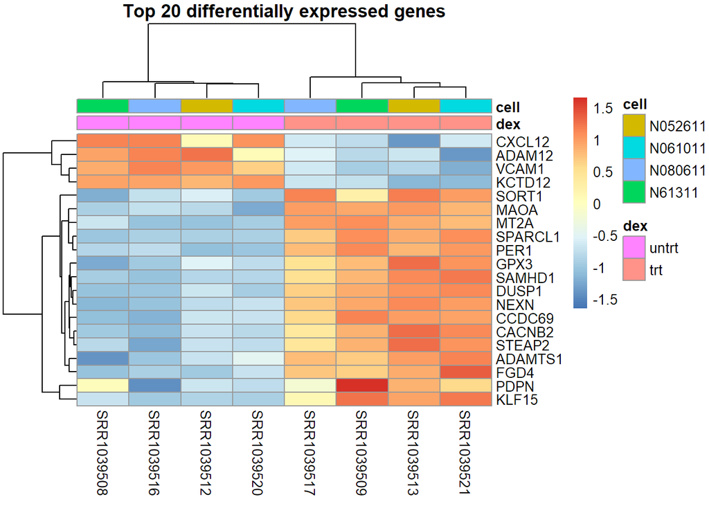

```r
# Take just the top 20 genes by adjusted p-value
# to capture the strongest and most reproducible signal in the data.
top_genes <- head(res_df$ensembl_id, 20)

# Use the SAME variance-stabilized values as the PCA (not raw counts), so a few very
# highly-expressed genes don't visually dominate the color scale.
mat <- assay(vsd)[top_genes, ]

# Re-label rows with gene symbols instead of Ensembl IDs so the heatmap is actually
# readable when shown on screen in the video.
rownames(mat) <- res_df$symbol[match(top_genes, res_df$ensembl_id)]

# Pull in sample metadata so the heatmap's column annotation bar shows treatment + donor.
annotation_col <- as.data.frame(colData(vsd)[, c("dex", "cell")])

# scale = "row" centers each gene around its OWN mean across samples. This turns the plot
# into a "relatively high vs. low" view per gene, which is what matters for differential
# expression: otherwise genes with naturally high baseline expression would visually
# swamp genes that are lower-expressed but still strongly regulated.
pheatmap(mat,
         scale = "row",
         annotation_col = annotation_col,
         main = "Top 20 differentially expressed genes")
```

### 6. Interpretation

```r
res_df[1:10, c("symbol", "log2FoldChange", "padj")]
```

```
##                  symbol log2FoldChange          padj
## ENSG00000152583 SPARCL1       4.559848 7.055960e-132
## ENSG00000165995  CACNB2       3.280119 3.830700e-131
## ENSG00000120129   DUSP1       2.936591 1.735862e-125
## ENSG00000101347  SAMHD1       3.754342 3.296820e-125
## ENSG00000189221    MAOA       3.341300 1.789522e-119
## ENSG00000211445    GPX3       3.716111 7.395423e-108
## ENSG00000157214  STEAP2       1.969256 1.493686e-102
## ENSG00000162614    NEXN       2.027830  3.358895e-99
## ENSG00000125148    MT2A       2.198752  3.527683e-93
## ENSG00000154734 ADAMTS1       2.334542  3.890888e-87
```

Several of our top hits re-cover genes already known from the literature to be glucocorticoid-responsive in this exact system. In the original analysis of this dataset, Himes et al. (2014, *PLoS One*, doi: 10.1371/journal.pone.0099625, GEO: GSE52778) reported 316 differentially expressed genes after dexamethasone treatment, including well-established glucocorticoid targets (DUSP1, KLF15, PER1, TSC22D3) alongside a less-studied gene, **CRISPLD2**, which they validated by qRT-PCR and went on to show modulates IL-1beta-induced cytokine expression in ASM cells. They additionally found that SNPs near CRISPLD2 were associated with inhaled corticosteroid resistance and bronchodilator response in two independent asthma GWAS cohorts, making it a strong pharmacogenetic gene candidate for asthma treatment response.

**Why this matters biologically:** glucocorticoids act by binding the glucocorticoid receptor, which then alters transcription of genes that dampen inflammatory signaling. Finding these specific genes from an independent analysis is a useful internal validation that this pipeline works (filtering → DESeq2 → shrinkage → significance calling).

### 7. Limitations and Next Steps

- Sample size is pretty small (n = 4 paired donors); rare or donor-specific responses may be underpowered to detect.
- This is a single time point (18 hours) and single dose (1 micromolar), so the dynamics of the glucocorticoid response over time/dose are not captured.
- Cultured, primary ASM cells in isolation may not fully reflect the *in vivo* airway environment (e.g., immune cell crosstalk is absent).
- A natural next step would be gene set / pathway enrichment (e.g., GO or Reactome) on the full significant gene list to characterize the response at a pathway level rather than gene-by-gene, or comparing this corticosteroid-naive response to RNA-seq from corticosteroid-resistant asthma patients.

**Data availability:** Himes BE et al. *RNA-Seq Transcriptome Profiling Identifies CRISPLD2 as a Glucocorticoid Responsive Gene that Modulates Cytokine Function in Airway Smooth Muscle Cells.* PLoS One. 2014;9(6):e99625. PMID: 24926665. Raw data: GEO accession GSE52778. Processed counts accessed via installing the Bioconductor `airway` package.

### Comments!

1. Elina Nemtsov: Elina - p75NTRKO RNA Seq Analysis Hi Elina, I really liked that you related your final project to your research on the p75 neurotrophin receptor and made it available on GitHub! Using the show/hide code options also makes trying to go through the code a lot easier. The QC scores and checks are great as well, it’s really easy to look at and know how good your dataset is for later analysis! My main suggestion would be using something like res_df$symbol <- mapIds(org.Hs.eg.db, keys = res_df$ensembl_id, column = “SYMBOL”, keytype = “ENSEMBL”, multiVals = “first”) to swap out the Ensemble codes with the actual gene names. As well, explaining more of the purpose of p75NTR would be helpful for others to know the significance of this research. Otherwise, an amazing analysis and comparison to the original study!
2. Amna Aleem: Using single cell RNA seq. to analyze EGFR-mutant transformed small cell lung cancer Hi Amna, this is a really great walkthrough of single cell RNA sequencing! I liked how you explored the Neuroendocrine and Non-neuroendocrine states, how they relate to lung cancer, and even explaining the original study that this dataset comes from, which is something I should have done in my own project! Watching through it I felt like I was learning how many more libraries can be used in R such as Seurat, which I would not have considered before this. My main suggestion is because I did not fully understand was the orange/pink in the back of the QC plots, and maybe next time you could use a box plot or explain that a little bit more! Otherwise, the rest of your explanations were very clear! This is a really great and detailed analysis which is comparable to a research paper. Awesome job!
3. Angel Hernandez: Homework 4 – Lipid Droplet Differential Expression Analysis in the Brain vs the Spinal Cord Oligodendroglia Hi Angel! This is a super in-depth analysis of postnatal mouse oligodendrocytes using the paper published by your lab but looking at a different aspect of it relating to cholesterol biosynthesis and storage genes. I like that you used the Seurat to count and sort the metadata of the genes before using them for the RNA Seq. Using the DotPlot for the lipid droplet genes is a nice touch, as it looks kind of like droplets falling down the page. Although maybe you could sort them from greatest to least in terms of percent expression for the viewer to more easily see the top expressed vs least expressed genes!  
   My main suggestion would be that you could spend a little less time on the background in the presentation/recording, and focus more on the Methodology/Data Analysis portions because there is so much great content to walkthrough here!! Overall, a very solid analysis with amazing graphs and explanations!
4. Nikhil Parab: Nikhil’s Homework 4: Transcriptional Effects of Persistent β2-Agonist Treatment Hi Nikhil, I had no idea we ended up looking at different sides of the same dataset with yours focusing on Albuterol instead, that is such a funny coincidence! As such, your additional background info on the genes combined with the references and usage of EnrichR really helps to tie it all together, which is something I missed in my own analysis. Cleaning up the genes before the analysis was helpful, but my suggestion for the Gene ID page would then be to replace the Ensemble Gene IDs with the actual gene names using something like: res_df$symbol <- mapIds(org.Hs.eg.db, keys = res_df$ensembl_id, column = “SYMBOL”, keytype = “ENSEMBL”, multiVals = “first”). Noting that the variability of treated vs untreated was grouped due to the donors was helpful as a reflection/possible limitation for the results and efficacy for Albuterol on different people. A future suggestion could be to also cross reference the genes across each person to see if there were any specific genes that made any patient more or less responsive to the Albuterol etc. Overall, great presentation and walkthrough of the data!
5. Andrea Torres: Hey Andrea, I’m really proud of you for sticking with it and figuring out how to make the HTML file work!! Your walkthrough is really clear and easy to follow! The volcano log plot was a really cool idea and helps to contrast the p-value along with prevalence for a gene, and solidifies the visualization aspect apart from just using a heatmap. A suggestion I would make would be explaining the PCA plot a bit more, for example why there’s Healthy and Periodontitis on both sides of the plot, and what the Variance means in this case. Your mentioned limitations including reliance on publicly available data is very interesting because that would make it different from a dataset done with a research group/lab. Overall, a really great presentation and walkthrough of your data, and congrats on making it work this time!! Nat